# Immunological single-cell analysis of mononuclear cord blood cells

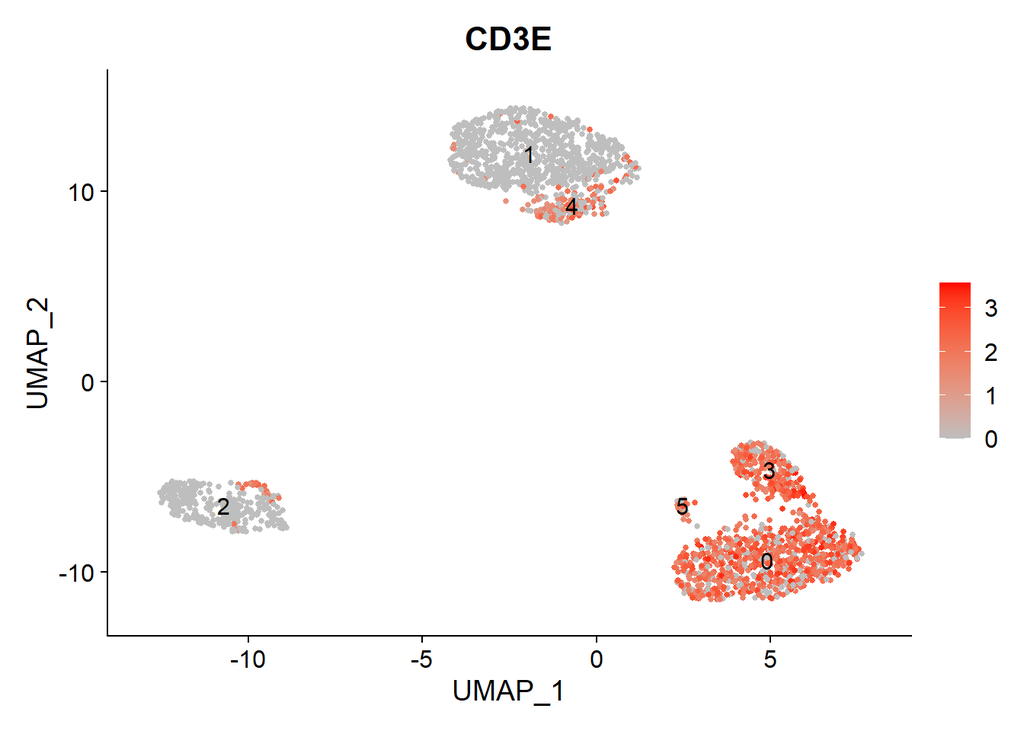

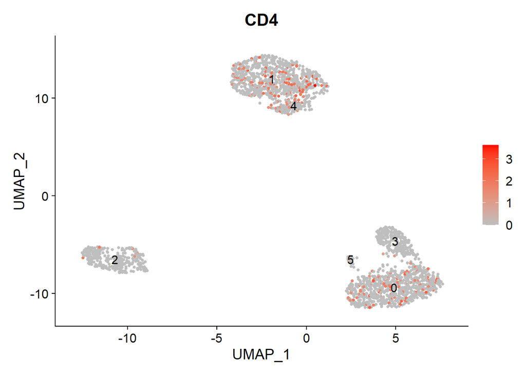

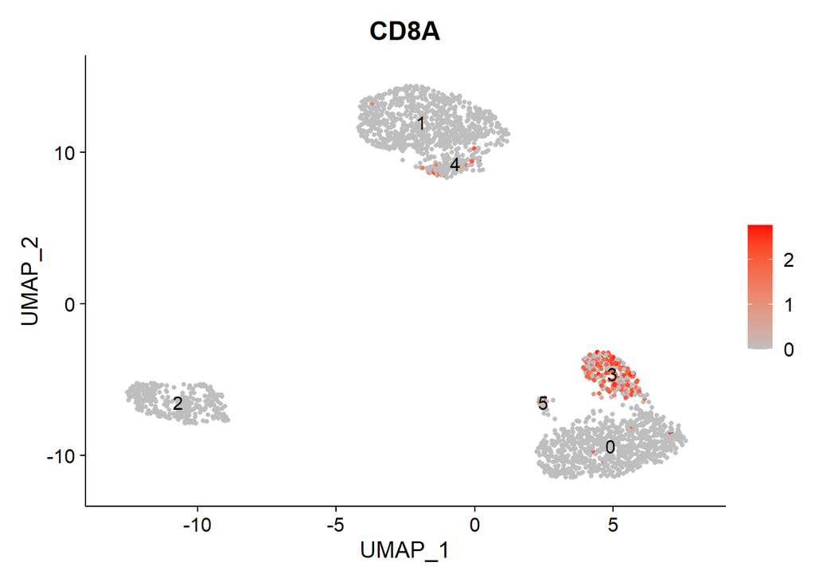

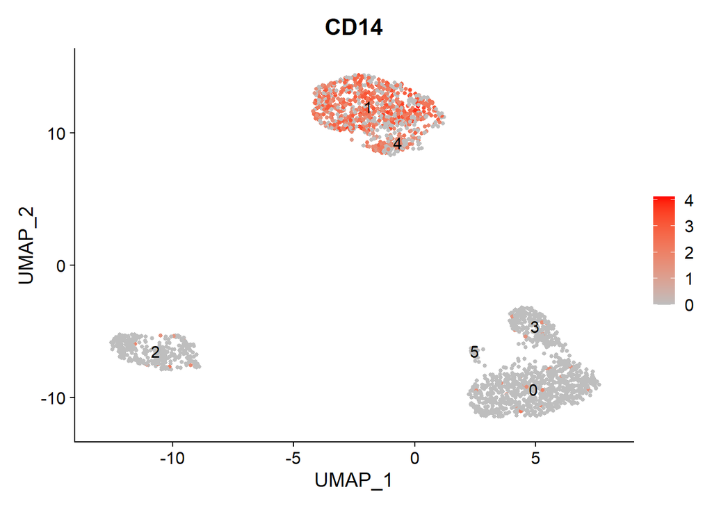

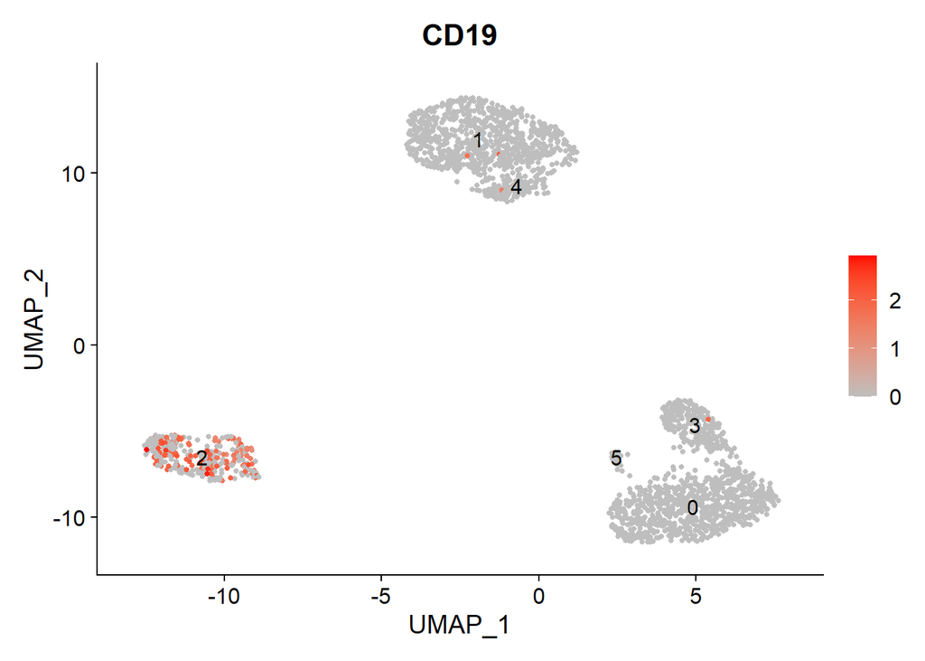

```r
#look into some key markers for immune cells
DefaultAssay(cbmc) <- 'RNA'
genes_rna <- c('CD3E', 'CD4', 'CD8A', 'CD14', 'CD19')
#CD3E - for T Cells
#CD4  - for CD4 T cells
#CD8A - for CD8A t cells
#CD14 - for myeloid cells
#CD19 - for B cells

#nice way to iterate in plotting
for (i in 1:length(genes_rna)){
    print(FeaturePlot(cbmc, reduction = 'umap', features = genes_rna[i], cols = c('grey','red'), pt.size = 1, label = TRUE))
}
```

Switch to the antibody array to plot the graphs.

```r
#look for the markers in the AB assay
DefaultAssay(cbmc) <- 'ab'
rownames(cbmc)
```

```
##  [1] "CD3"    "CD4"    "CD8"    "CD45RA" "CD56"   "CD16"   "CD10"   "CD11c"
##  [9] "CD14"   "CD19"   "CD34"   "CCR5"   "CCR7"
```

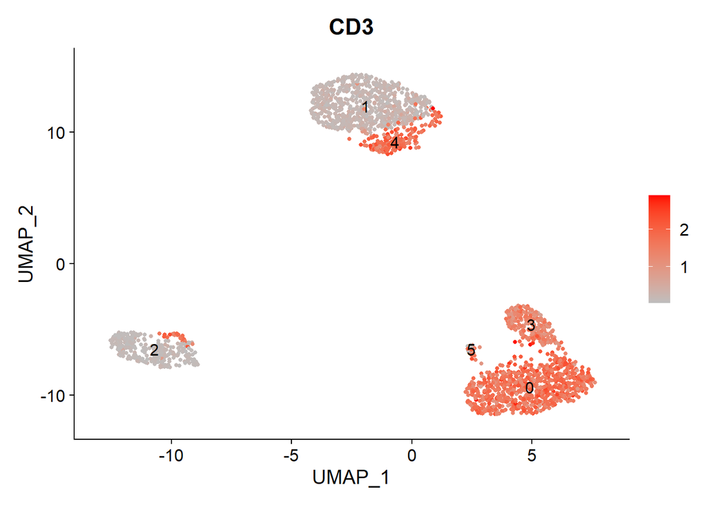

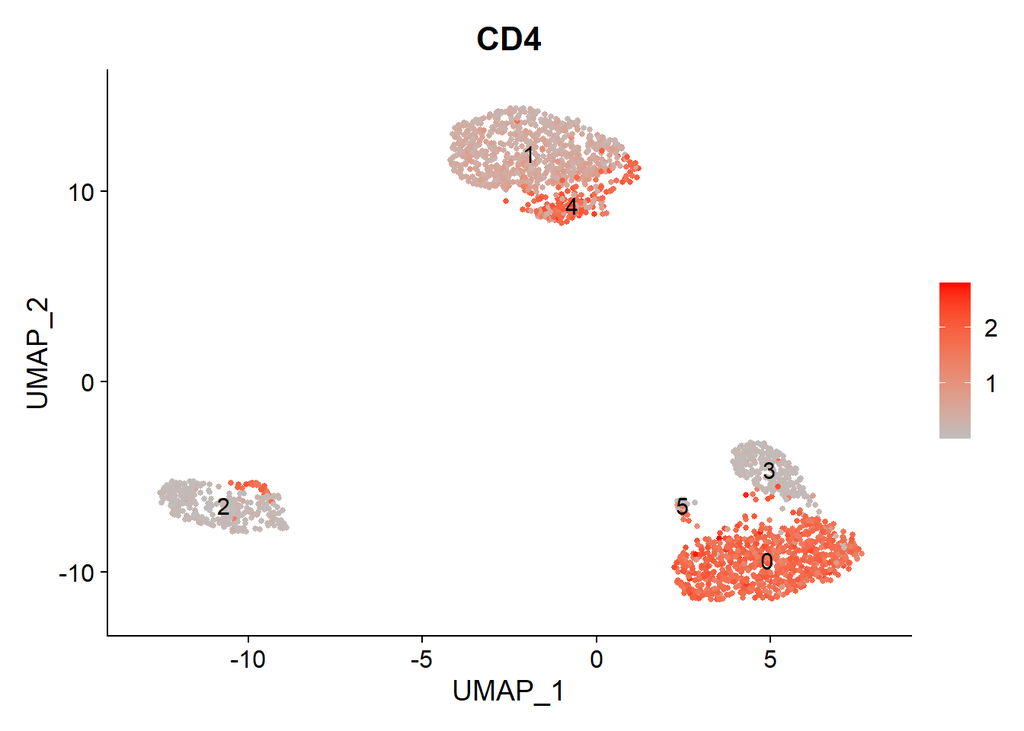

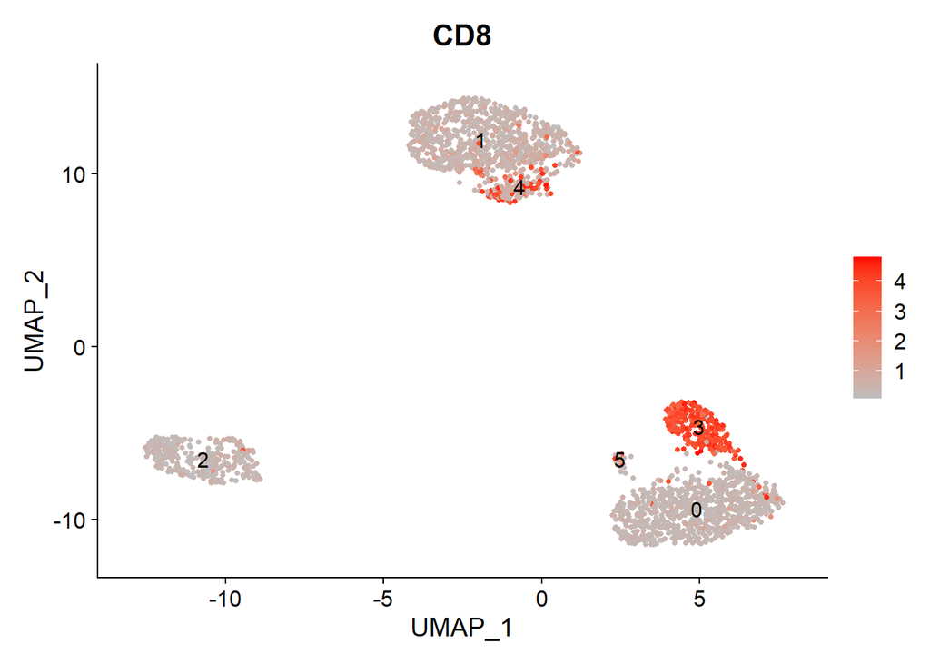

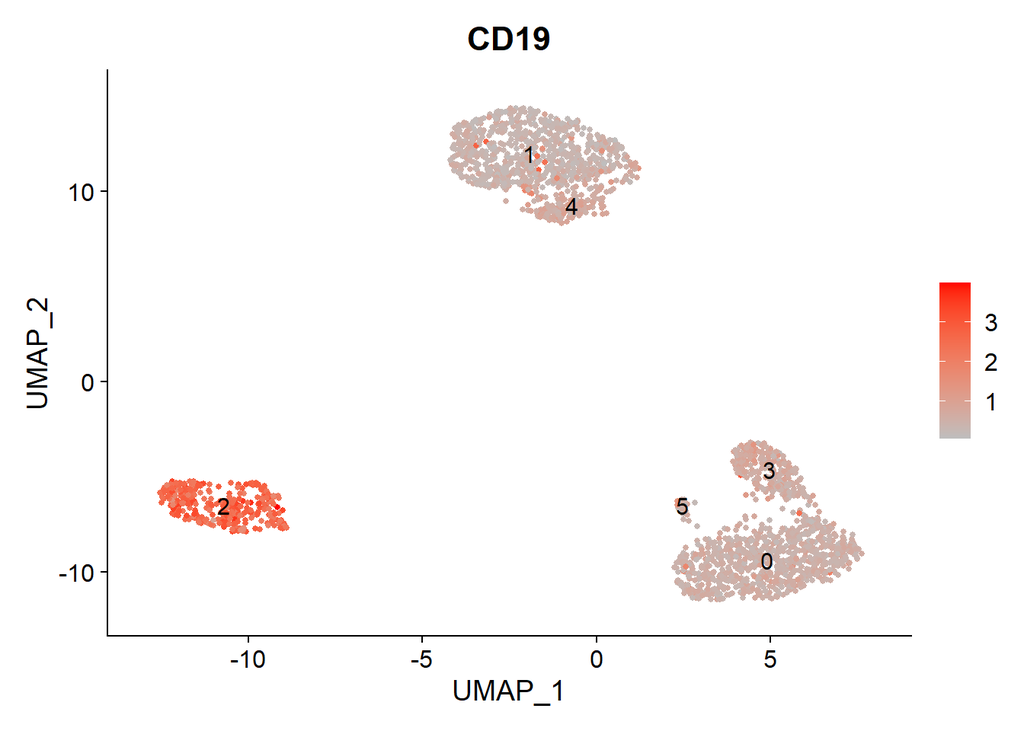

```r
#look for the markers in the AB assay
genes_ab <- c('CD3', 'CD4', 'CD8', 'CD19')
for (i in 1:length(genes_ab)){
    print(FeaturePlot(cbmc, reduction = 'umap', features = genes_ab[i], cols = c('grey','red'), pt.size = 1, label = TRUE))
}
```

# Cluster markers

To confirm the conclusions made earlier, we will make another visualization. Switching to the RNA array. Performing differential gene expression for each cluster.

```r
#swith to the RNA assay
DefaultAssay(cbmc) <- 'RNA'
```

Removal from analysis of risobomal genes and genes of receptors that do not help to describe the identity of the cell. TCRs only describe a T cell receptor.

```r
#look into the DE expression of each cluster
featurescbmc <- rownames(cbmc)
markers.remove <- grep(pattern = "^TRAV|^TRBV|^TRGV|^TRDV|^RPL|^RPS", x = rownames(cbmc), value = TRUE) #remove TCR variable genes and ribosomal genes from the analysis
featurescbmc <- featurescbmc[!(featurescbmc%in%markers.remove)]
cbmc.markers <- FindAllMarkers(object = cbmc, only.pos = TRUE, min.pct = 0.25, logfc.threshold = 0.25, features = featurescbmc)
```

The graph shows where which cluster is located.

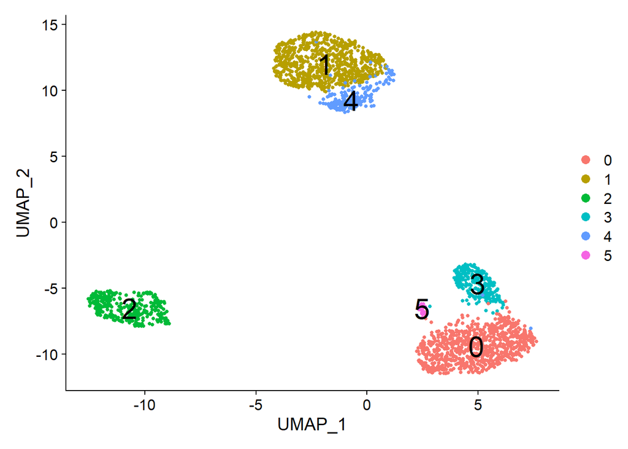

```r
DimPlot(cbmc, reduction = 'umap', label = TRUE, pt.size = 1, label.size = 8)
```

Adding the first 10 marker genes to the list of designated genes. For example, in cluster 0, most of us see T cells, which indicates a high quality of the dataset and our calculations. Cluster 1 is characterized by genes associated with myeloid cells. By inserting the found genes on the site https://maayanlab.cloud/Enrichr/, you can find the cells with which they are associated.

```r
#visualise top 10 markers by avg Fold Change (log2)
top10 <- cbmc.markers %>% group_by(cluster) %>% top_n(n = 10, wt = avg_log2FC)
top10
```

```
## # A tibble: 60 x 7
## # Groups:   cluster [6]
##        p_val avg_log2FC pct.1 pct.2 p_val_adj cluster gene
##        <dbl>      <dbl> <dbl> <dbl>     <dbl> <fct>   <chr>
##  1 3.56e-193       1.89 0.881 0.31  7.29e-189 0       TRBC2
##  2 2.89e-192       1.96 0.856 0.261 5.92e-188 0       IL7R
##  3 3.51e-191       1.66 0.946 0.484 7.20e-187 0       LDHB
##  4 1.30e-181       1.68 0.881 0.282 2.67e-177 0       IL32
##  5 4.15e-178       2.00 0.759 0.207 8.51e-174 0       ITM2A
##  6 1.37e-157       1.63 0.791 0.246 2.81e-153 0       CD3E
##  7 4.30e-152       1.45 0.877 0.302 8.82e-148 0       CD3D
##  8 4.57e-142       1.58 0.778 0.241 9.38e-138 0       TRAC
##  9 1.47e-104       1.45 0.606 0.191 3.01e-100 0       CD3G
## 10 7.19e- 93       1.45 0.542 0.167 1.47e- 88 0       LINC00861
## # ... with 50 more rows
```

With the help of the tool ‘AverageExpression’, we can calculate the average gene expression

```r
#look into the average heatmap
cluster.averages_cbmc <- AverageExpression(cbmc, assay = "RNA", return.seurat = TRUE) # , verbose = FALSE)
```

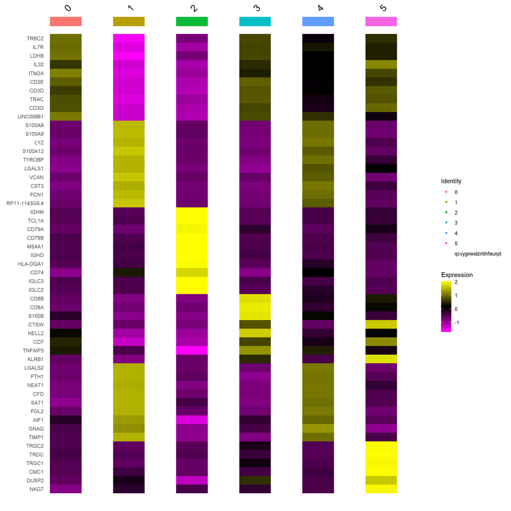

```r
#look into the average heatmap
DoHeatmap(cluster.averages_cbmc, features = top10$gene)
```

Using a dot-plot that shows the number of genes and percentage of the expressed cells. This plot is important since we can have 1 cell that is overexpressed, and then the entire previous heat map looks more expressed in a certain area. This graph shows the size of the point. For example, we suggest gene expression at a low percentage. This means that this gene does not pass quality control.

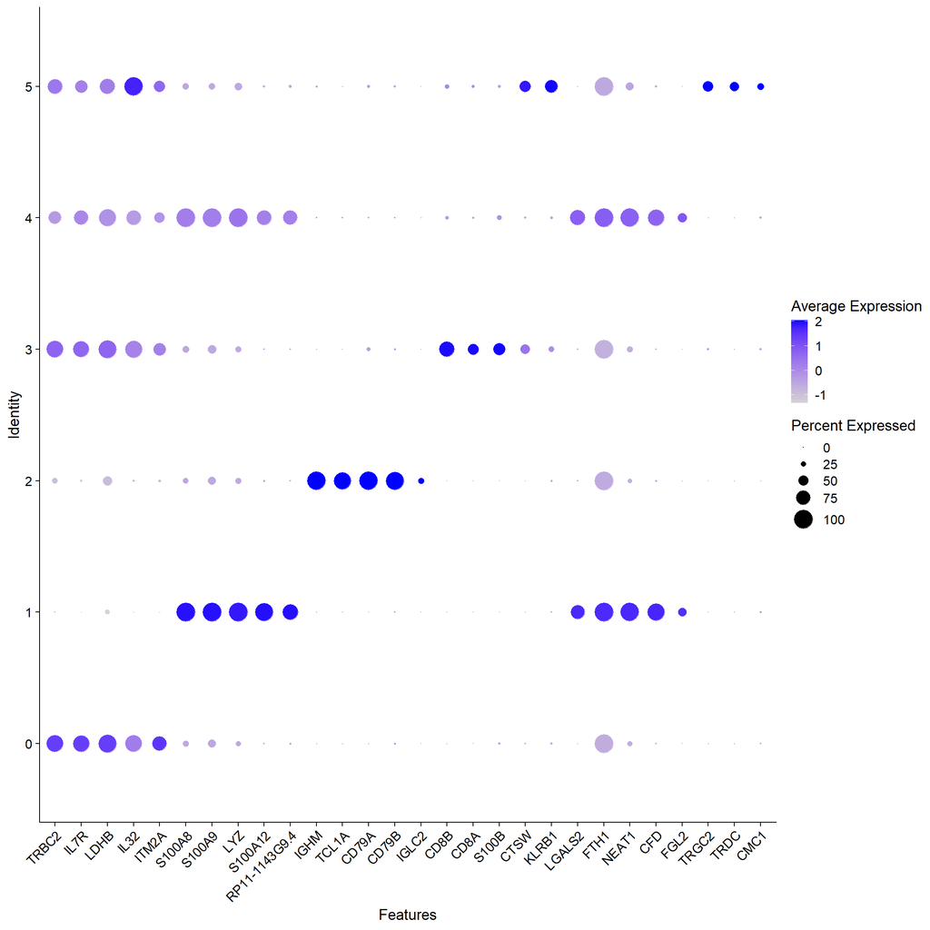

```r
#look into the DotPlot
top5 <- cbmc.markers %>% group_by(cluster) %>% top_n(n = 5, wt = avg_log2FC)
DotPlot(cbmc, features = unique(top5$gene), dot.scale = 8) + RotatedAxis()
```

We found cells in the first 4 clusters, but the previous plot in cluster 5 is not clear which cells. They are similar to T cells, but differ slightly and are a small subpopulation. Testing the CCR7 and CD45RA markers of naive T cells. They were not found in cluster 5. Taking marker genes for memory cells, negative loop response, and differential factor. It becomes clear that in cluster 5, based on the level of expression of the S100A4 gene, there are memory cells.

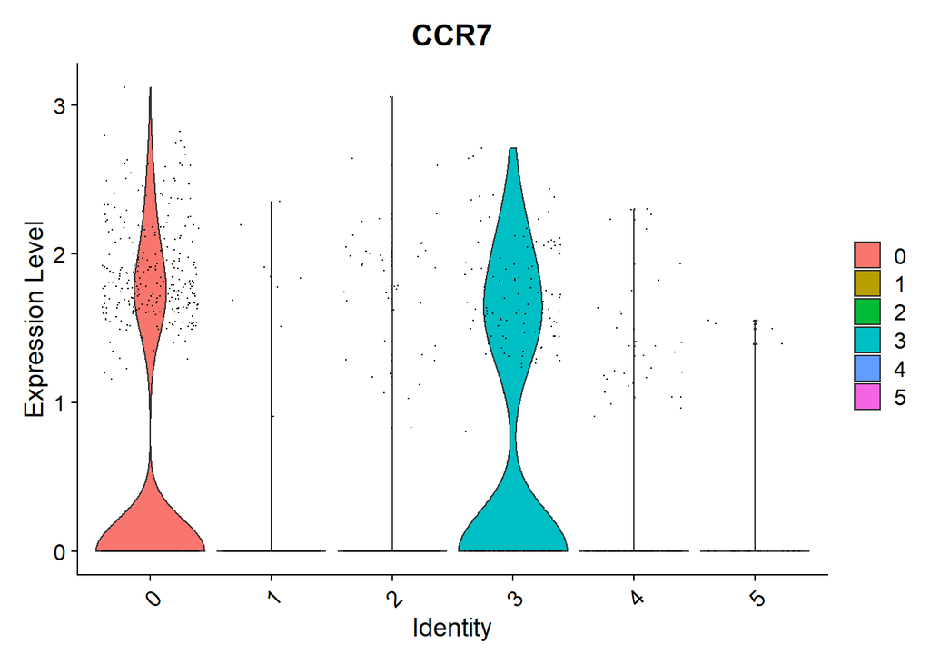

```r
#Lets find out a bit more about our T cells
#for Naive T cells
VlnPlot(cbmc, features = 'CCR7')
```

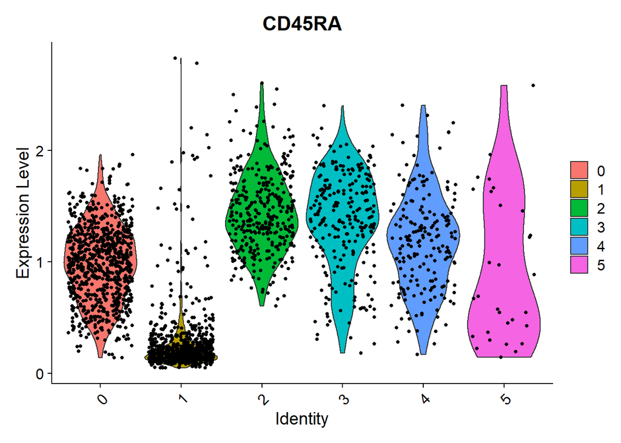

```r
VlnPlot(cbmc, features = 'CD45RA', assay = 'ab')
```

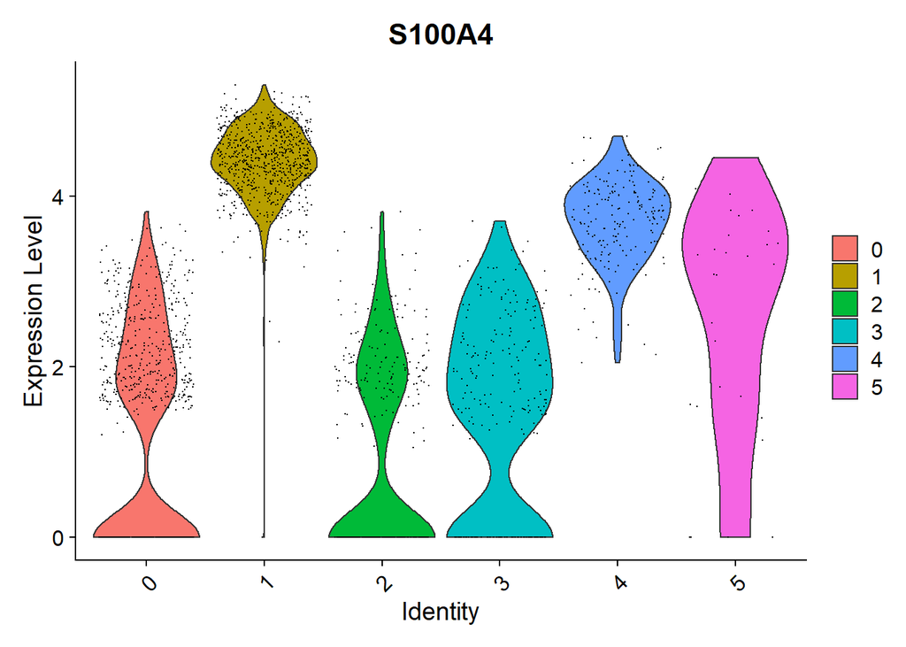

```r
#for cluster 5
VlnPlot(cbmc, features = 'S100A4') #memory subtype
```

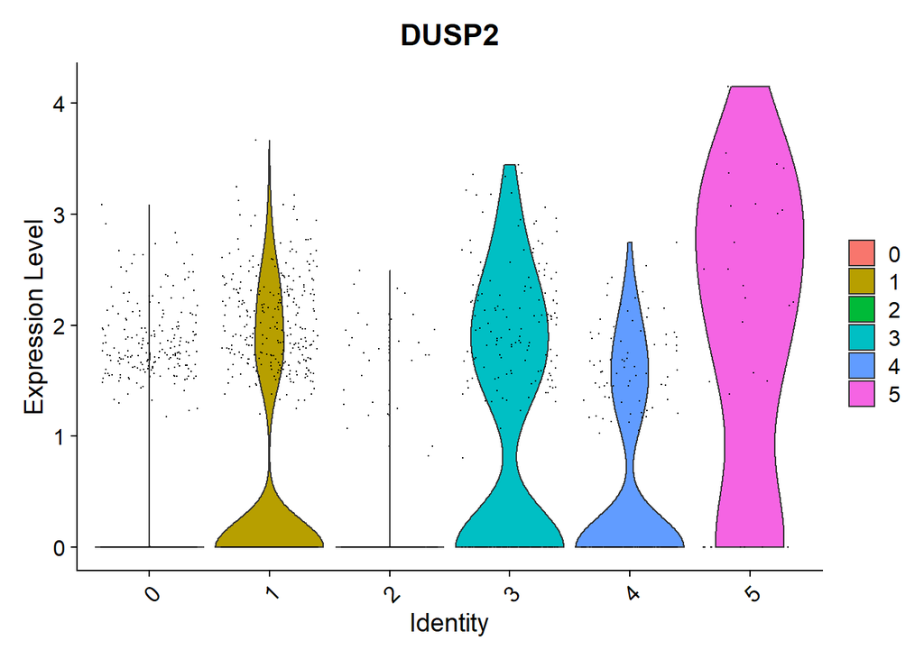

```r
VlnPlot(cbmc, features = 'DUSP2') #negative feedback loop
```

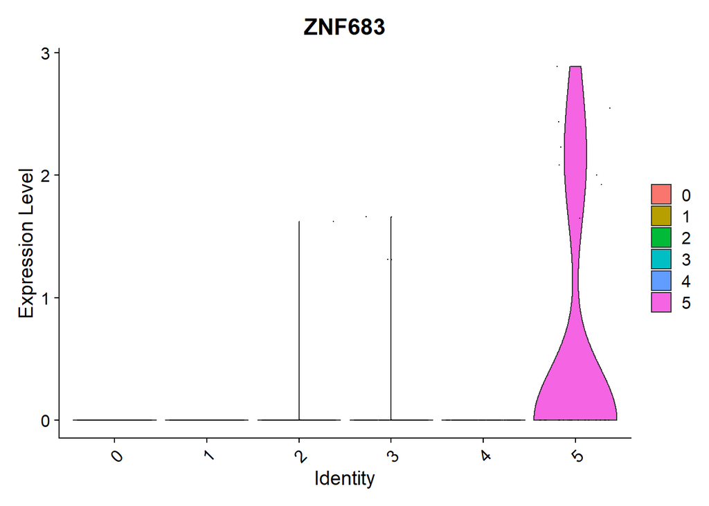

```r
VlnPlot(cbmc, features = 'ZNF683') #differentiation factor
```

Metadata table based on found clusters

```r
head(cbmc@meta.data)
```

```
##                     orig.ident nCount_RNA nFeature_RNA nCount_ab nFeature_ab
## CGTTGGGCAGATCGGA SeuratProject       2732         1012      6973          13
## TCCCGATAGGAGTTTA SeuratProject       2452          936      7211          13
## TTCTCAAAGCGTAGTG SeuratProject       1984          875      5357          13
## AGATTGCTCCTTTCTC SeuratProject       2162          881      5758          13
## GTGTGCGCACGGCTAC SeuratProject       2165          870      4822          13
## CACTCCACATGTTGAC SeuratProject       2503          990      4746          13
##                  percent.mito RNA_snn_res.0.5 seurat_clusters
## CGTTGGGCAGATCGGA   0.02269400               3               3
## TCCCGATAGGAGTTTA   0.03670473               0               0
## TTCTCAAAGCGTAGTG   0.03528226               0               0
## AGATTGCTCCTTTCTC   0.03145236               0               0
## GTGTGCGCACGGCTAC   0.03140878               0               0
## CACTCCACATGTTGAC   0.02796644               0               0
```

Renaming clusters to identified cells in metadata by looping

```r
#assign names for your clusters:
for(i in 1:nrow(cbmc@meta.data)){
    if(cbmc@meta.data$seurat_clusters[i] == 0){
        cbmc@meta.data$cluster_names[i] <- 'CD4 T-cells'
    }
    if(cbmc@meta.data$seurat_clusters[i] == 1){
        cbmc@meta.data$cluster_names[i] <- 'Myeloid'
    }
    if(cbmc@meta.data$seurat_clusters[i] == 2){
        cbmc@meta.data$cluster_names[i] <- 'B cells'
    }
    if(cbmc@meta.data$seurat_clusters[i] == 3){
        cbmc@meta.data$cluster_names[i] <- 'CD8 T-cells'
    }
    if(cbmc@meta.data$seurat_clusters[i] == 4){
        cbmc@meta.data$cluster_names[i] <- 'Myeloid-T doublets'
    }
    if(cbmc@meta.data$seurat_clusters[i] == 5){
        cbmc@meta.data$cluster_names[i] <- 'T memory'
    }
}
```

Metadata with a new column with the name of the cells that are expressed in the cluster.

```r
#check meta.data again
head(cbmc@meta.data)
```

```
##                     orig.ident nCount_RNA nFeature_RNA nCount_ab nFeature_ab
## CGTTGGGCAGATCGGA SeuratProject       2732         1012      6973          13
## TCCCGATAGGAGTTTA SeuratProject       2452          936      7211          13
## TTCTCAAAGCGTAGTG SeuratProject       1984          875      5357          13
## AGATTGCTCCTTTCTC SeuratProject       2162          881      5758          13
## GTGTGCGCACGGCTAC SeuratProject       2165          870      4822          13
## CACTCCACATGTTGAC SeuratProject       2503          990      4746          13
##                  percent.mito RNA_snn_res.0.5 seurat_clusters cluster_names
## CGTTGGGCAGATCGGA   0.02269400               3               3   CD8 T-cells
## TCCCGATAGGAGTTTA   0.03670473               0               0   CD4 T-cells
## TTCTCAAAGCGTAGTG   0.03528226               0               0   CD4 T-cells
## AGATTGCTCCTTTCTC   0.03145236               0               0   CD4 T-cells
## GTGTGCGCACGGCTAC   0.03140878               0               0   CD4 T-cells
## CACTCCACATGTTGAC   0.02796644               0               0   CD4 T-cells
```

The plot with the names of the clusters.

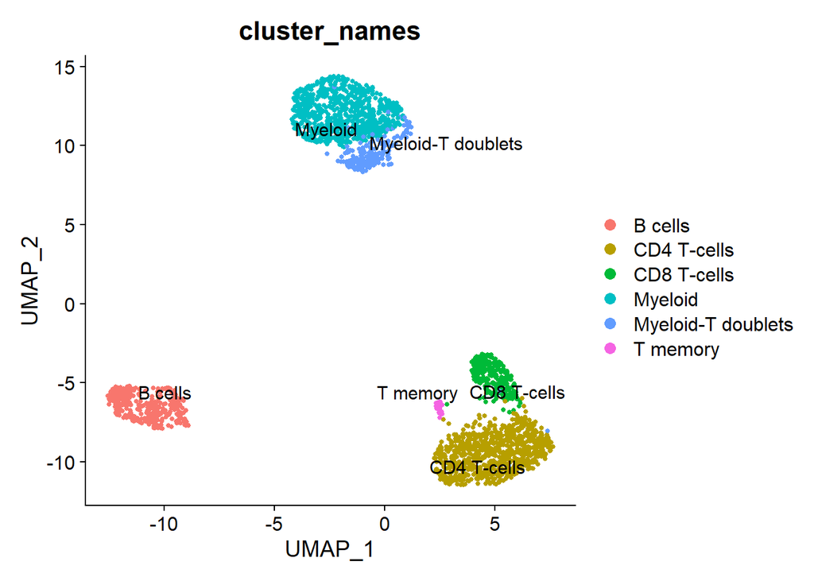

```r
#DimPlot new cluster names
DimPlot(cbmc, reduction = 'umap', label = TRUE, pt.size = 1, label.size = 4, repel = TRUE, group.by = 'cluster_names') #notice the group.by parameter
```

A useful function for plotting the dependence of any parameter from a column in the metadata of our array.

```r
#you can assign idents to any column of meta.data you want!
Idents(cbmc) <- 'cluster_names'
levels(cbmc)
```

```
## [1] "CD8 T-cells"        "CD4 T-cells"        "T memory"
## [4] "Myeloid-T doublets" "Myeloid"            "B cells"
```

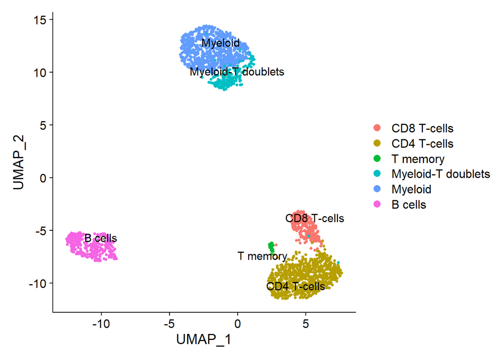

```r
DimPlot(cbmc, reduction = 'umap', label = TRUE, pt.size = 1, label.size = 4, repel = TRUE)
```

# Visualize Ab signal

```r
DefaultAssay(cbmc) <- 'ab'
```

Various methods for imaging the signal from antibodies.

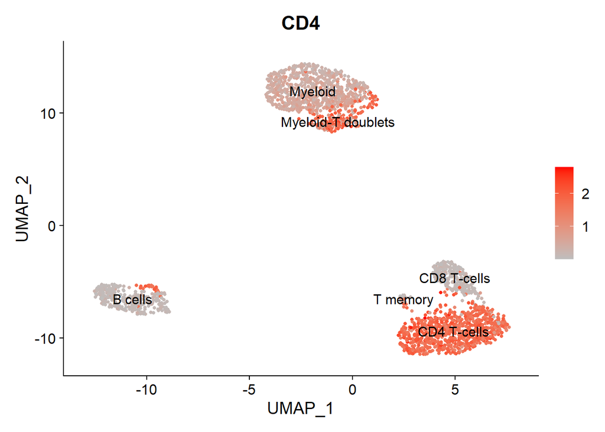

```r
#With feature umap
FeaturePlot(cbmc, reduction = 'umap', features = 'CD4', cols = c('grey','red'), pt.size = 1, label = TRUE, label.size = 4)
```

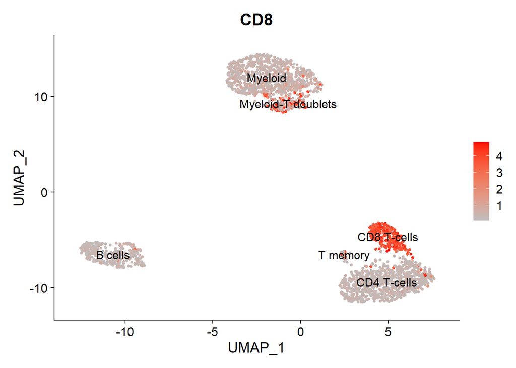

```r
FeaturePlot(cbmc, reduction = 'umap', features = 'CD8', cols = c('grey','red'), pt.size = 1, label = TRUE, label.size = 4)
```

These plots show the dependence of the level of cell expression on the type of cells. In addition, it is also possible to correlate the saturation of points on the graph with the found cells.

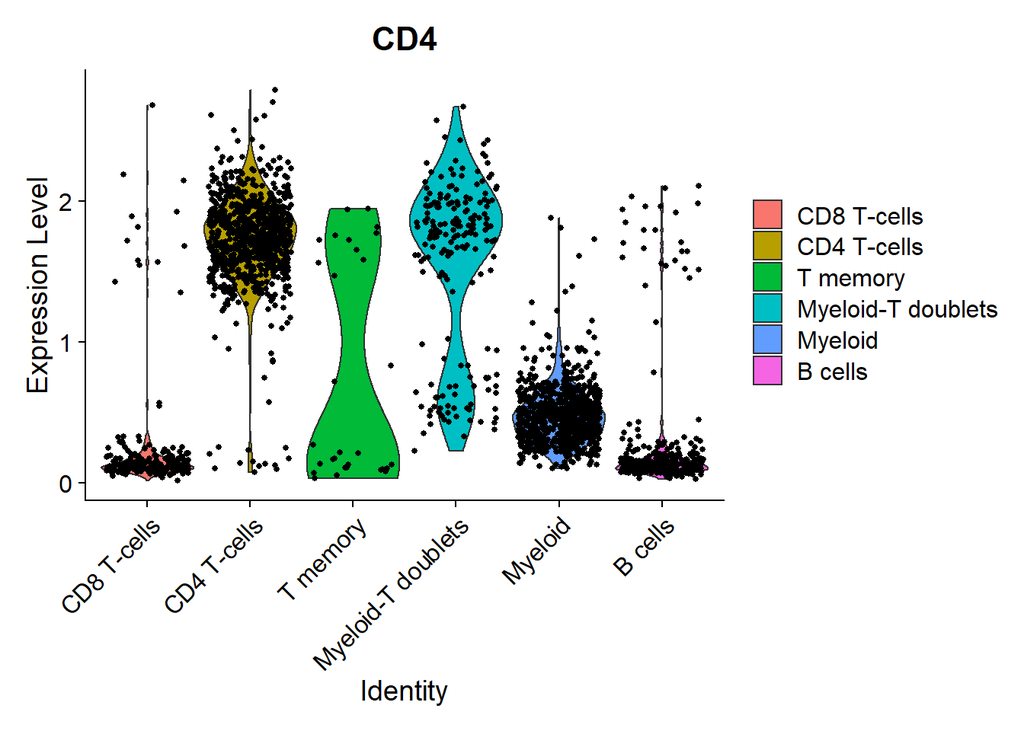

```r
#With VlnPlot
VlnPlot(cbmc, features = 'CD4')
```

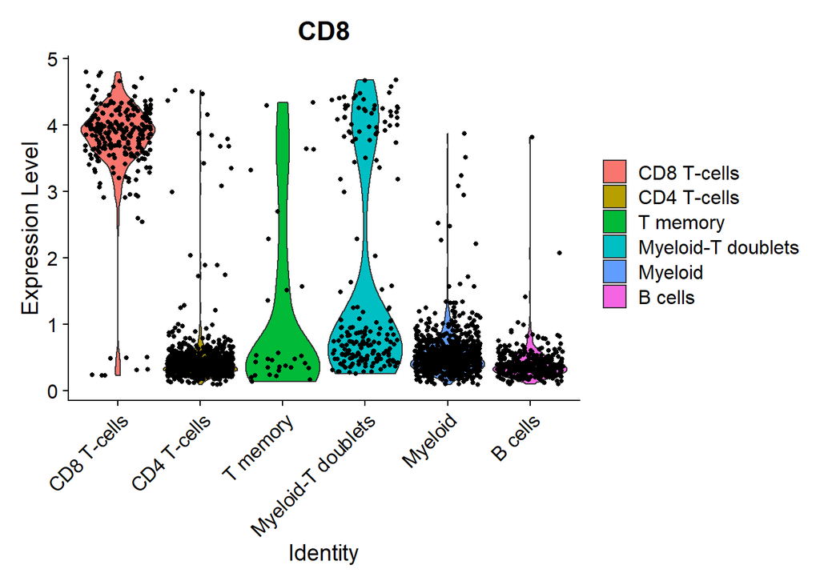

```r
VlnPlot(cbmc, features = 'CD8')
```

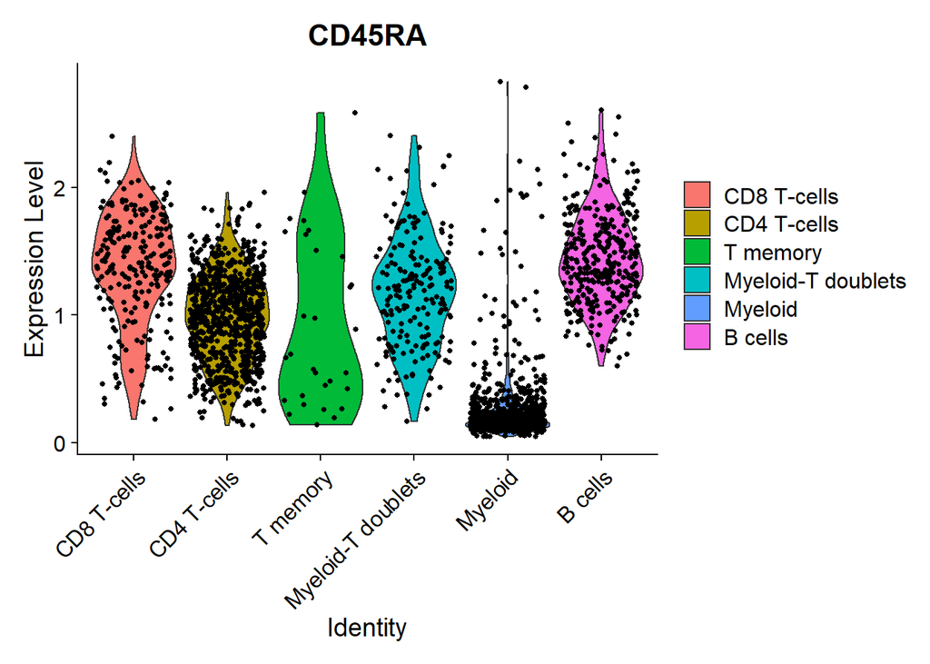

```r
VlnPlot(cbmc, features = 'CD45RA')
```

In this plot, we see the distribution of antibodies within the cell.

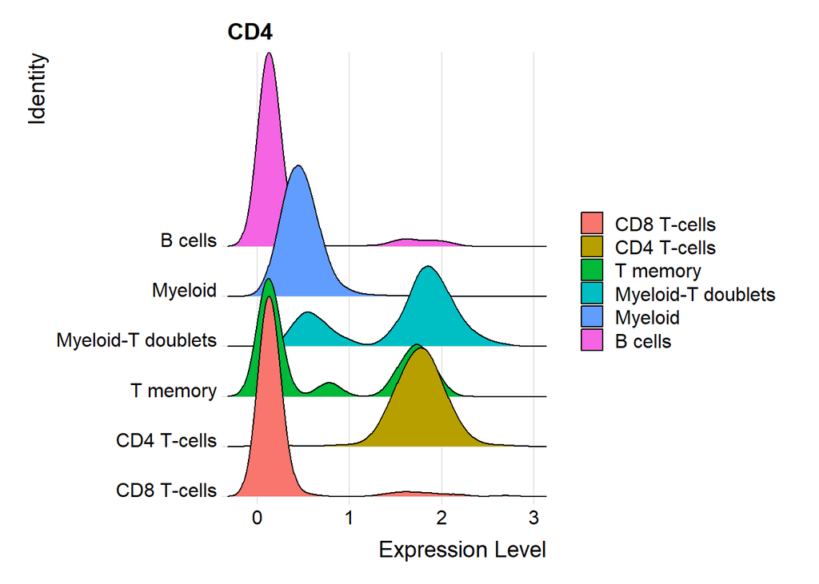

```r
#With RidgePlot
RidgePlot(cbmc, features = 'CD4')
```

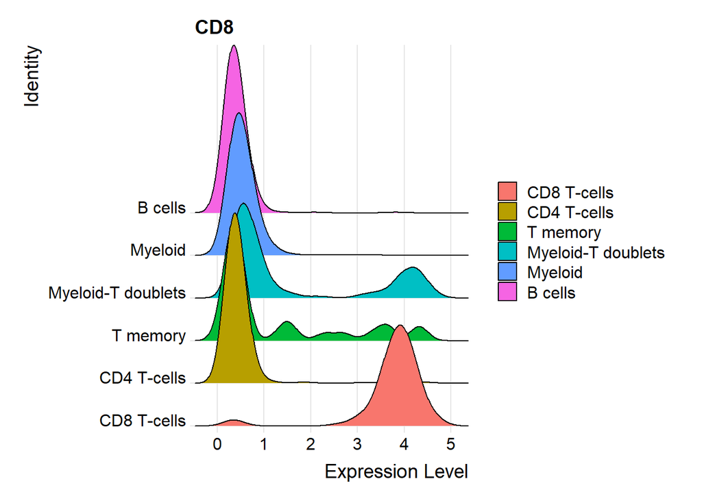

```r
RidgePlot(cbmc, features = 'CD8')
```

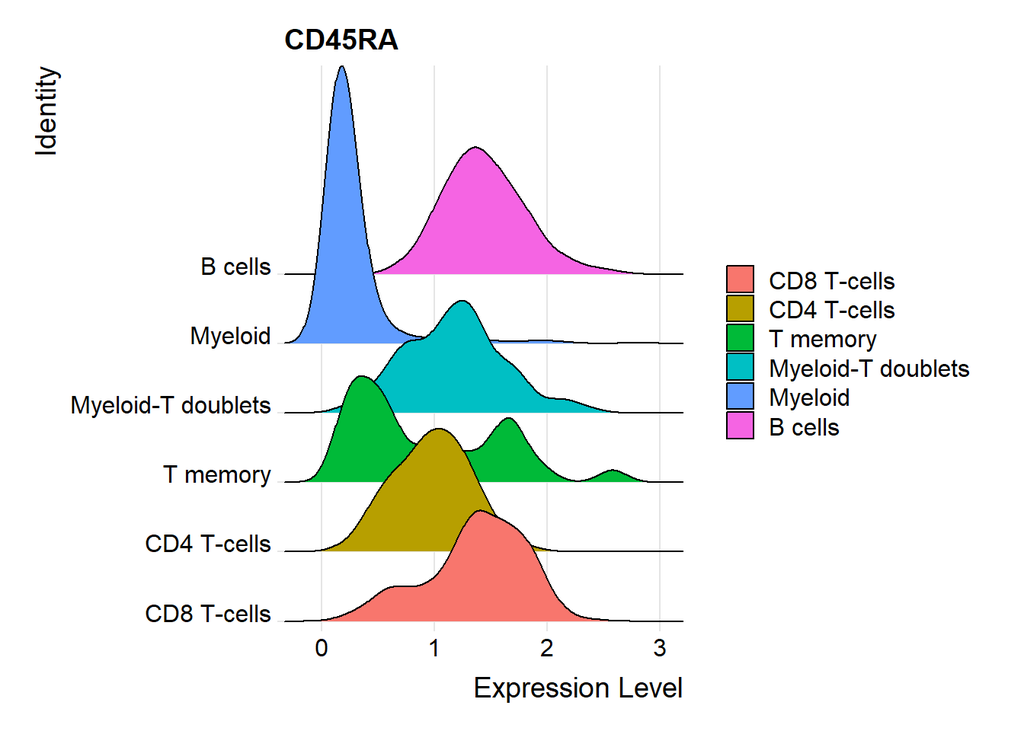

```r
RidgePlot(cbmc, features = 'CD45RA')
```

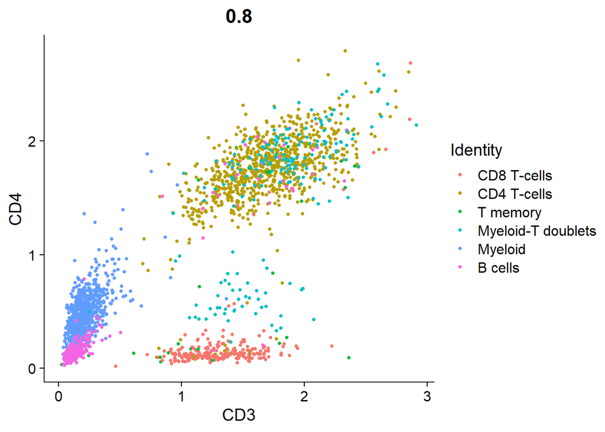

```r
#With FeatureScatter
FeatureScatter(cbmc, feature1 = 'CD3', feature2  = 'CD4', pt.size = 1)
```

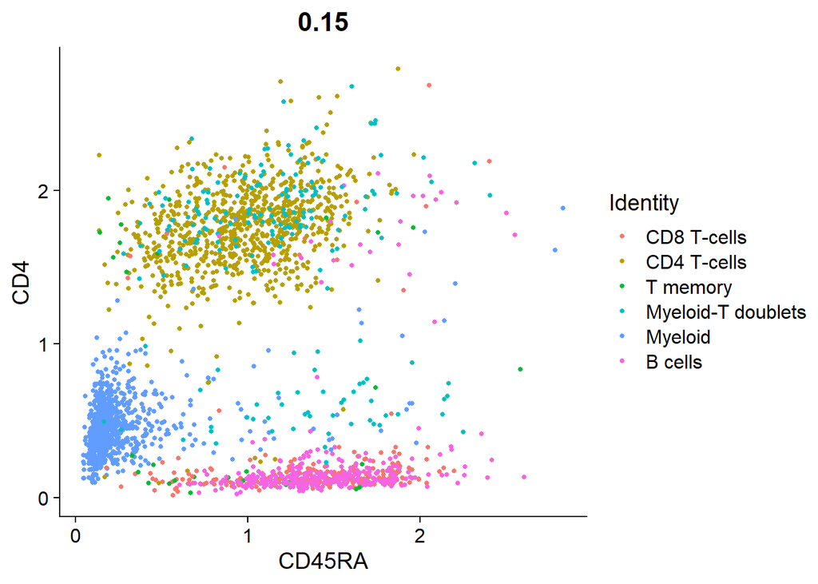

```r
FeatureScatter(cbmc, feature1 = 'CD45RA', feature2  = 'CD4', pt.size = 1)
```

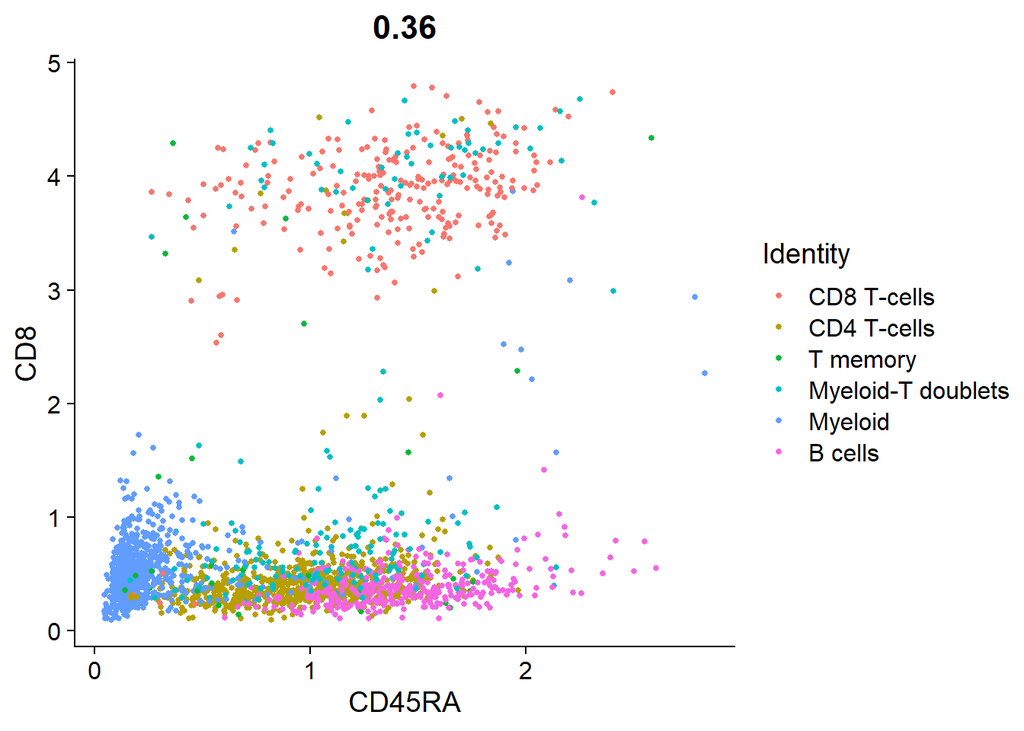

```r
FeatureScatter(cbmc, feature1 = 'CD45RA', feature2  = 'CD8', pt.size = 1)
```

```
##
## Listening on http://127.0.0.1:7059
```

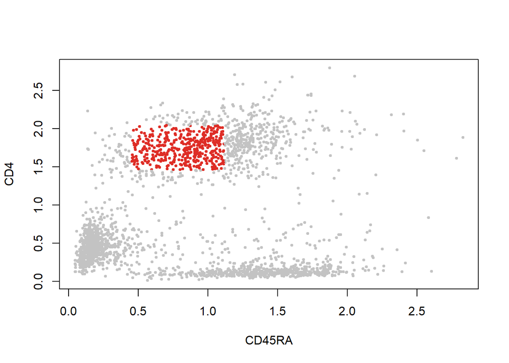

```r
#gate selected cells!
plot <- FeatureScatter(cbmc, feature1 = 'CD45RA', feature2  = 'CD4', pt.size = 1)
select.cells <- CellSelector(plot = plot)
```

```r
#look inside into the gating string
head(select.cells)
```

```
## [1] "TTCTCAAAGCGTAGTG" "AGATTGCTCCTTTCTC" "GTGTGCGCACGGCTAC" "CACTCCACATGTTGAC"
## [5] "GCGGGTTGTCAGATAA" "CACATAGTCCAGTAGT"
```

```r
DefaultAssay(cbmc) <- 'ab'
#run pca on AB data
cbmc <- RunPCA(cbmc, features = rownames(cbmc), reduction.name = 'ab_pca')
```

```
## PC_ 1
## Positive:  CD16, CD10, CCR5, CD34, CD56, CCR7
## Negative:  CD3, CD4, CD8, CD45RA, CD19, CD14
## PC_ 2
## Positive:  CD11c, CD56, CD34, CD10, CD16, CD14
## Negative:  CD3, CD4, CD45RA, CCR7, CD8, CCR5
## PC_ 3
## Positive:  CD14, CD4, CD11c, CD3, CD34, CCR7
## Negative:  CD19, CD45RA, CD8, CCR5, CD10, CD56
## PC_ 4
## Positive:  CD19, CD4, CD56, CD10, CD14, CD45RA
## Negative:  CD8, CD11c, CD3, CD34, CCR7, CD16
## PC_ 5
## Positive:  CD45RA, CD11c, CD14, CD56, CD19, CCR5
## Negative:  CD10, CCR7, CD16, CD34, CD3, CD4
```

```r
cbmc
```

```
## An object of class Seurat
## 20514 features across 2390 samples within 2 assays
## Active assay: ab (13 features, 0 variable features)
##  1 other assay present: RNA
##  4 dimensional reductions calculated: pca, tsne, umap, ab_pca
```

We can cut out the elbow graph data for antibodies more than 10.

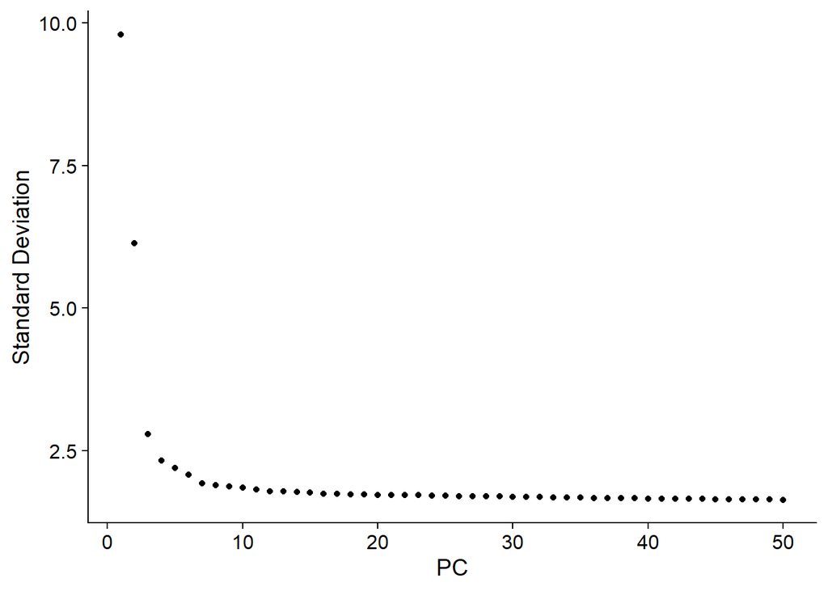

```r
#Elbowplot to determine the number of the PCs
ElbowPlot(object = cbmc, ndims = 50, reduction = 'pca')
```

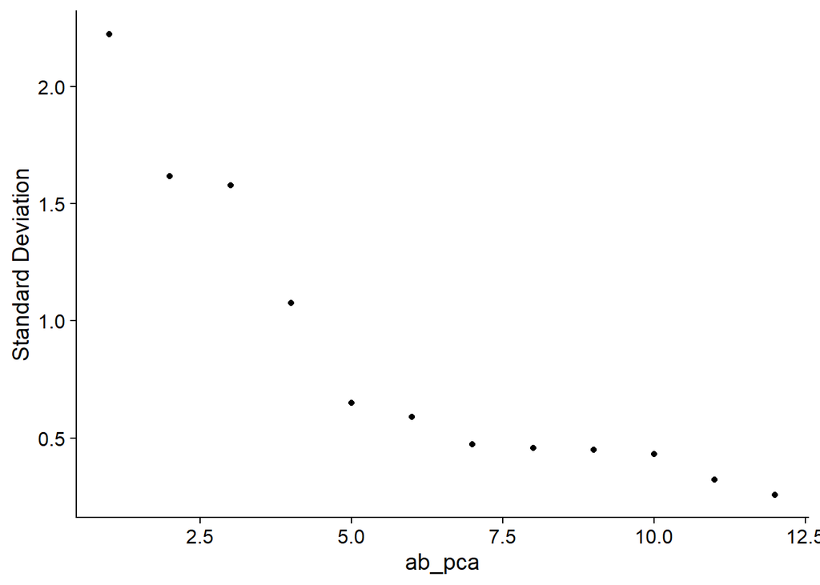

```r
ElbowPlot(object = cbmc, ndims = 50, reduction = 'ab_pca')
```

```r
#run the multimodal neighbours on BOTHs PCA reduction (rna and ab)
cbmc <- FindMultiModalNeighbors(
  cbmc, reduction.list = list("pca", "ab_pca"),
  dims.list = list(1:10, 1:10), modality.weight.name = "RNA.weight"
)
```

```
## Calculating cell-specific modality weights
```

```
## Finding 20 nearest neighbors for each modality.
```

```
## Calculating kernel bandwidths
```

```
## Finding multimodal neighbors
```

```
## Constructing multimodal KNN graph
```

```
## Constructing multimodal SNN graph
```

```r
#Find your clusters
cbmc <- FindClusters(cbmc, graph.name = "wsnn", algorithm = 3, resolution = 0.5, verbose = FALSE)
```

```r
#run UMAP
cbmc <- RunUMAP(cbmc, nn.name = "weighted.nn", reduction.name = "wnn.umap", reduction.key = "wnnUMAP_")
```

Cluster plots from 2 arrays. It can be seen from the combined plot that the clusters CD4 and CD8 that were previously closed to each other are now at a greater distance, which is logical and shown in the analysis above.

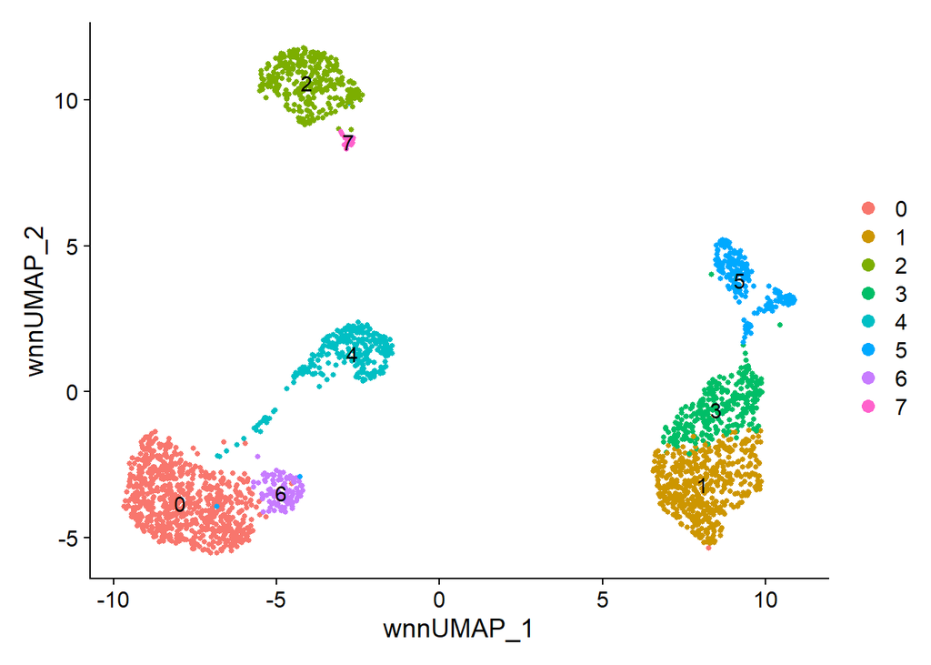

```r
#plot the results
DimPlot(cbmc, reduction = 'wnn.umap', label = TRUE, pt.size = 1, label.size = 4) #not the reduction parameter
```

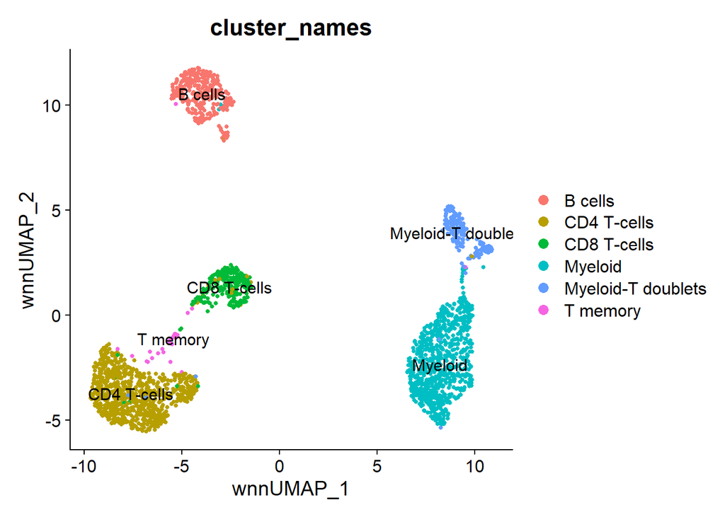

```r
DimPlot(cbmc, reduction = 'wnn.umap', label = TRUE, pt.size = 1, label.size = 4, group.by = 'cluster_names') #look on the previous clustering
```

This violin plot shows how much better the data from the RNA compared to the data from the antibody array. For example, a cluster of T cells 6 is better described by an array of antibodies. Cluster 7 RNA array is mainly used to describe B cells such as plasma cells.

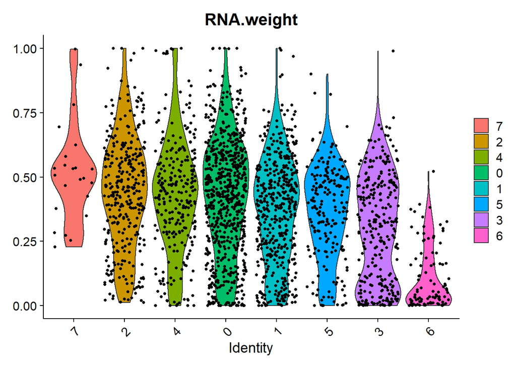

```r
#which cluster is clustererd with the help of RNA information the most?
VlnPlot(cbmc, features = "RNA.weight", group.by = 'seurat_clusters', sort = TRUE, pt.size = 1)
```

# Discussion